# Lipid Data Template

June 10, 2021

## Upload Data

### *Expression Data*

A lipid expression data file called **“lipid_edata.csv”** was uploaded to pmart. The column that designates unique molecules was marked as **“LipidCommonName”**. The original scale of the data was abundance and was changed to log2. The value to denote missing data was **“NA”** and the expression data **was not already** normalized.

### *Biomolecule Information*

No biomolecule information was uploaded.

### *Sample Information*

An associated sample information file was also uploaded called **“lipid_fdata.csv”**. Trimmed sample names **were not** used. The column in the sample information file which indicates sample names was designated as **“Sample_Name”**.

## Group Samples

### *Grouping Information*

This table summarizes all the user specified main effects or covariates in pmart. The “Selected Column Name” denotes the name of the column in the sample information file assigned as a main effect or covariate.

| Main Effect or Covariate | Selected Column Name |
| --- | --- |
| First Main Effect | Condition |
| Second Main Effect | None selected |
| First Covariate | None selected |
| Second Covariate | None selected |

### *Number of Samples per Main Effects*

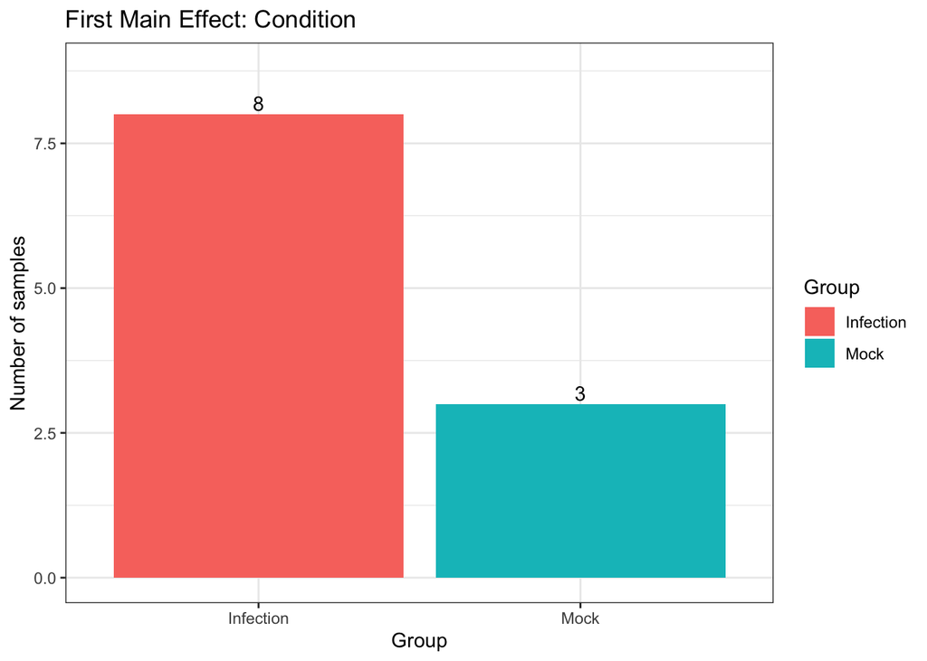

## Data Summary

### *Summary Table*

|  | Data |
| --- | --- |
| Class | lipidData |
| Unique Sample_Names (f_data) | 11 |
| Unique LipidCommonNames (e_data) | 84 |
| Rows (e_meta) | NA |
| Missing Observations | 318 |
| Proportion Missing | 0.344 |
| Samples per group: Mock | 3 |
| Samples per group: Infection | 8 |

### *Missing Value Table*

In the table below, the first column denotes the sample and the second is the missing number of observations. The third column represents the second as a percentage of the total number of observations for that sample.

|  | Missing Observations | Proportion Missing |
| --- | --- | --- |
| Mock1 | 23 | 0.274 |
| Mock2 | 20 | 0.238 |
| Mock3 | 20 | 0.238 |
| Infection1 | 27 | 0.321 |
| Infection2 | 26 | 0.310 |
| Infection3 | 28 | 0.333 |
| Infection4 | 32 | 0.381 |
| Infection6 | 33 | 0.393 |
| Infection7 | 38 | 0.452 |
| Infection8 | 36 | 0.429 |
| Infection9 | 35 | 0.417 |

## Filter

Filters **were** applied. A total of 3 filters were applied. See the table below for a descriptions of the filters and the order.

### *Summary of Applied Filters*

[output not shown]

### *Molecule Filter*

A molecule filter was applied to the data, which removes biomolecule(s) (LipidCommonNames) not having at least the minimum number of samples (Min Number Molecules).

### *CV Filter*

A coefficient of variation (CV) filter was applied to the data which removes biomolecule(s) (LipidCommonNames) with a CV greater than the threshold (Max CV).

### *imd-ANOVA Filter*

An ANOVA filter can be applied to the data which removes biomolecule(s) (LipidCommonNames) not having at least a minimum number of non-missing values per group (Min ANOVA). Additionaly, an IMD (independence of missing data) filter can be applied to the data, removing biomolecules not having at least a minimum number of non-missing values (Min G-Test) in at least one of the groups.

### *rMD Filter*

rMD filters were not applied to the data.

### *Custom Filter*

Custom filters were not applied to the data.

## Normalization

### *Manual*

| Attribute | Value |
| --- | --- |
| Subset Function | all |
| Subset Parameters |  |
| Normalization Function | mean |

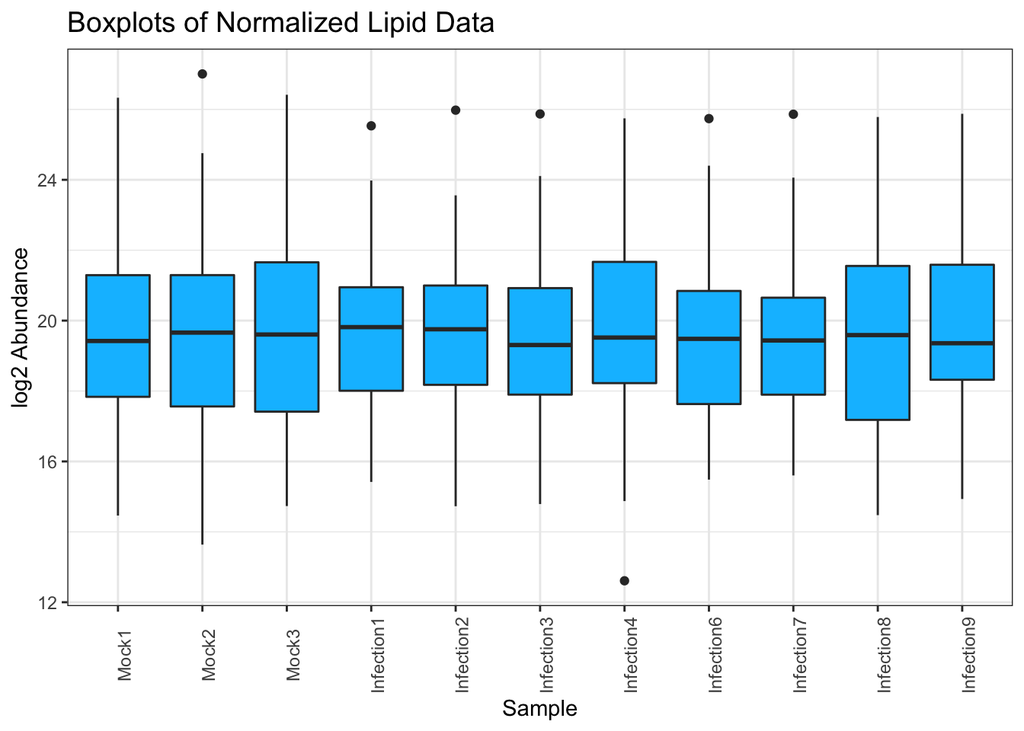